# Анализ избыточности (Redundancy analysis, RDA)

## Анализ избыточности (Redundancy analysis, RDA)

- Связь нескольких наборов переменных
- Анализ избыточности, теория и практика
- Проверка значимости ординации
- Выбор оптимальной модели
- Частный анализ избыточности и компоненты объясненной инерции
- Компоненты объясненной изменчивости

### Вы сможете

- Проводить анализ избыточности
- Оценивать долю объясненной инерции
- Интерпретировать компоненты по нагрузкам переменных
- Строить ординацию объектов в пространстве компонент
- Проверять значимость модели ординации при помощи пермутационного теста
- Разделять объясненную инерцию на компоненты, связанные с разными наборами переменных, при помощи частного анализа избыточности

## Связь нескольких наборов переменных

## Что будет определять генетическую структуру в колониях бабочек?

### Пример: генетика бабочек *Euphydryas editha*

Частоты разных аллелей фосфоглюкоизомеразы и данные о факторах среды для 16 колоний бабочек *Euphydryas editha* в Калифорнии и Орегоне (данные McKechnie et al., 1975)

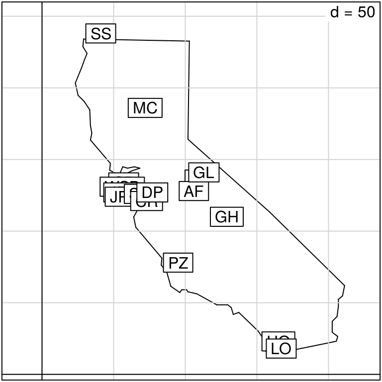

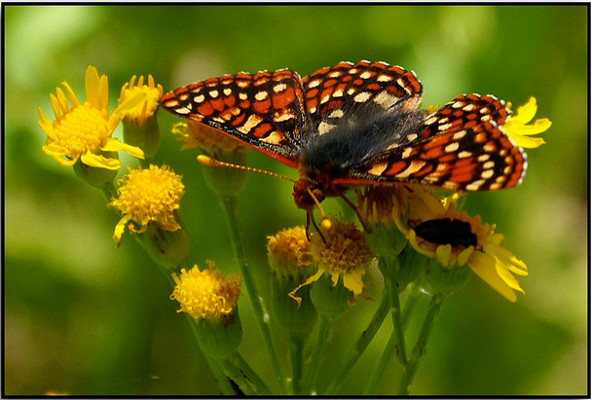

Winged Wonder by [Roger Lynn on Flickr](https://flic.kr/p/6CMVsC)

## Анализ избыточности

## Анализ избыточности (RDA, Redundancy analysis)

- Метод прямой ординации (ограниченной ординации = constrained ordination)
- Основан на анализе главных компонент
- Нужно две матрицы данных: матрица зависимых переменных и матрица предикторов
- Нужно найти такие компоненты матрицы зависимых переменных, которые являются линейными комбинациями предикторов и отражают максимум изменчивости.

## Непрямая ординация и множественная регрессия

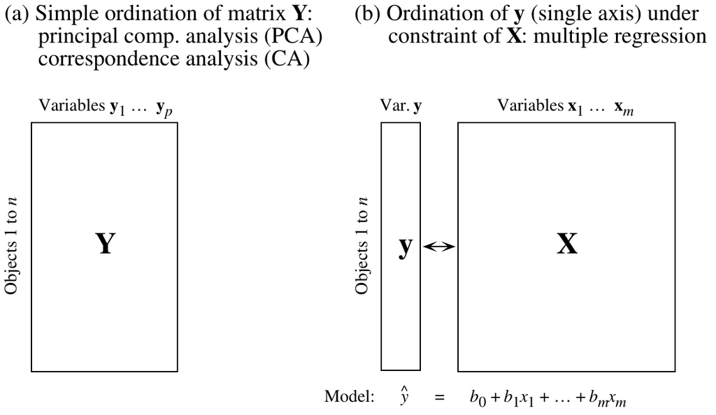

Рис. из Legendre, Legendre, 1998

## Прямая (ограниченная) ординация

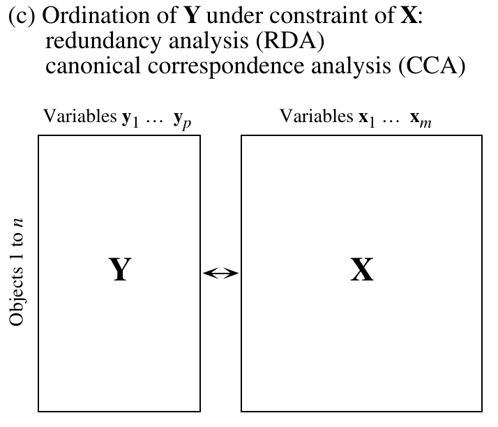

Рис. из Legendre, Legendre, 1998

## Если множественную линейную регрессию можно обобщить для нескольких зависимых переменных — получится RDA

\[y _{i} = b _0 + b _1 x _{1i} + b _2 x _{2i} + ... + b _k x_{ki} + \epsilon _{i}\]

Уравнение множественной линейной регрессии можно переписать в виде матриц.

\[\left[\begin{array}{c} y_1 \\ y_2 \\ \vdots \\ y_n \end{array}\right] = \left[\begin{array}{cc} 1 & x_{1,1} & x_{1,2} & \cdots & x_{1,k} \\ 1 & x_{2,1} & x_{2,2} & \cdots & x_{2,k} \\ \vdots & \vdots & \vdots & \ddots & \vdots \\ 1 & x_{n,1} & x_{n,2} & \cdots & x_{n,k} \end{array}\right] \cdot \left[\begin{array}{c} b _0 \\ b _1 \\ b _2 \\ \vdots \\ b _k \end{array}\right] + \left[\begin{array}{c} \epsilon _1 \\ \epsilon _2 \\ \vdots \\ \epsilon _n \end{array}\right] \]

Сокращенная форма записи: \(\mathbf{y} = \mathbf{X} \mathbf{b} + \mathbf{\epsilon}\), причем \(\mathbf{b} = (\mathbf{X}^T\mathbf{X})^{-1}(\mathbf{X}^T \mathbf{y})\).

### Во множественной линейной регрессии \(\mathbf{\hat y} = \mathbf{X}(\mathbf{X}^T\mathbf{X})^{-1}(\mathbf{X}^T\mathbf{y})\)

### В RDA зависимая переменная — матрица, т.е. \(\mathbf{\hat Y} = \mathbf{X}(\mathbf{X}^T\mathbf{X})^{-1}(\mathbf{X}^T\mathbf{Y})\),

## Принцип RDA

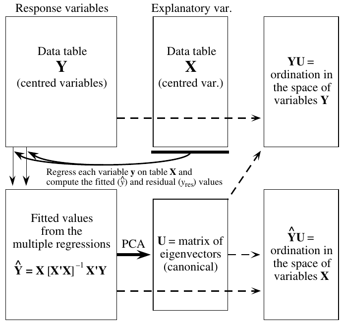

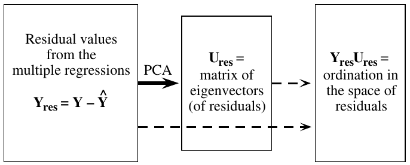

Рис. из Legendre, Legendre, 1998

## Условия применимости RDA

- Независимость наблюдений (сайтов)
- Линейная зависимость переменных-откликов от предикторов
- Не должно быть мультиколлинеарности предикторов
- Сайтов должно быть значительно больше, чем предикторов (как в регрессии, см. "проклятие размерности")

## Подготовка данных к RDA

## Подготовка исходных данных

Нужно две матрицы: зависимые переменные (генетические данные для разных сайтов) и предикторы (данные об условиях среды, координатах и т.п.).

Структура исходных данных

- `$xy` — координаты колоний
- `$envir` — 4 фактора среды для колоний
- `$genet` — частоты 6 аллелей в колониях
- `$contour` — карта Калифорнии

```r
library(ade4)
data(butterfly)
str(butterfly)
```

```
## List of 5
##  $ xy     :'data.frame': 16 obs. of  2 variables:
##   ..$ x: num [1:16] 41 57 56 57 58 67 73 165 167 77 ...
##   ..$ y: num [1:16] 238 134 131 127 124 126 121 23 18 127 ...
##  $ envir  :'data.frame': 16 obs. of  4 variables:
##   ..$ Altitude     : num [1:16] 500 800 570 550 550 380 930 650 600 1500 ...
##   ..$ Precipitation: num [1:16] 43 20 28 28 28 15 21 10 10 19 ...
##   ..$ Temp_Max     : num [1:16] 98 92 98 98 98 99 99 101 101 99 ...
##   ..$ Temp_Min     : num [1:16] 17 32 26 26 26 28 28 27 27 23 ...
##  $ genet  :'data.frame': 16 obs. of  6 variables:
##   ..$ 0.4 : num [1:16] 0 0 0 0 0 0 0 10 14 0 ...
##   ..$ 0.6 : num [1:16] 3 16 6 4 1 2 0 21 26 1 ...
##   ..$ 0.8 : num [1:16] 22 20 28 19 8 19 15 40 32 6 ...
##   ..$ 1   : num [1:16] 57 38 46 47 50 44 50 25 28 80 ...
##   ..$ 1.16: num [1:16] 17 13 17 27 35 32 27 4 0 12 ...
##   ..$ 1.3 : num [1:16] 1 13 3 3 6 3 8 0 0 1 ...
##  $ contour:'data.frame': 59 obs. of  4 variables:
##   ..$ x1: num [1:59] 29 103 102 159 211 ...
##   ..$ y1: num [1:59] 234.1 232.6 164.1 113.3 61.9 ...
##   ..$ x2: num [1:59] 103 102 159 211 210 ...
##   ..$ y2: num [1:59] 232.6 164.1 113.3 61.9 54.8 ...
##  $ Spatial:
```

```
## Formal class 'SpatialPolygons' [package "sp"] with 4 slots
##   .. ..@ polygons   :List of 1
##   .. .. ..$ :Formal class 'Polygons' [package "sp"] with 5 slots
##   .. .. .. .. ..@ Polygons :List of 1
##   .. .. .. .. .. ..$ :Formal class 'Polygon' [package "sp"] with 5 slots
##   .. .. .. .. .. .. .. ..@ labpt  : num [1:2] 110 122
##   .. .. .. .. .. .. .. ..@ area   : num 17741
##   .. .. .. .. .. .. .. ..@ hole   : logi FALSE
##   .. .. .. .. .. .. .. ..@ ringDir: int 1
##   .. .. .. .. .. .. .. ..@ coords : num [1:60, 1:2] 29 103 102 159 211 ...
##   .. .. .. .. .. .. .. .. ..- attr(*, "dimnames")=List of 2
##   .. .. .. .. .. .. .. .. .. ..$ : NULL
##   .. .. .. .. .. .. .. .. .. ..$ : chr [1:2] "x1" "y1"
##   .. .. .. .. ..@ plotOrder: int 1
##   .. .. .. .. ..@ labpt    : num [1:2] 110 122
##   .. .. .. .. ..@ ID       : chr "contour"
##   .. .. .. .. ..@ area     : num 17741
##   .. ..@ plotOrder  : int 1
##   .. ..@ bbox       : num [1:2, 1:2] 23.3 13.5 211.2 234.1
##   .. .. ..- attr(*, "dimnames")=List of 2
##   .. .. .. ..$ : chr [1:2] "x" "y"
##   .. .. .. ..$ : chr [1:2] "min" "max"
##   .. ..@ proj4string:Formal class 'CRS' [package "sp"] with 1 slot
##   .. .. .. ..@ projargs: chr NA
```

## Создадим переменные с более короткими названиями для удобства

```r
gen <- butterfly$genet
head(gen, 1)
```

```
##    0.4 0.6 0.8  1 1.16 1.3
## SS   0   3  22 57   17   1
```

```r
env_geo <- cbind(butterfly$envir, butterfly$xy)
head(env_geo, 1)
```

```
##    Altitude Precipitation Temp_Max Temp_Min  x   y
## SS      500            43       98       17 41 238
```

## Нужно ли стандартизовать зависимые переменные?

```r
summary(gen)
```

```
##       0.4             0.6             0.8             1
##  Min.   : 0.00   Min.   : 0.00   Min.   : 1.0   Min.   :25.0
##  1st Qu.: 0.00   1st Qu.: 2.75   1st Qu.:12.5   1st Qu.:36.8
##  Median : 0.00   Median : 4.50   Median :18.0   Median :47.0
##  Mean   : 1.75   Mean   : 7.19   Mean   :18.6   Mean   :51.2
##  3rd Qu.: 0.25   3rd Qu.: 7.50   3rd Qu.:23.5   3rd Qu.:59.2
##  Max.   :14.00   Max.   :26.00   Max.   :40.0   Max.   :92.0
##       1.16           1.3
##  Min.   : 0.0   Min.   : 0.00
##  1st Qu.:10.0   1st Qu.: 0.00
##  Median :17.0   Median : 3.00
##  Mean   :17.2   Mean   : 4.12
##  3rd Qu.:27.0   3rd Qu.: 6.50
##  Max.   :35.0   Max.   :14.00
```

- Нет, можно оставить так, т.к. масштаб не сильно различается

## Линейны ли связи между переменными?

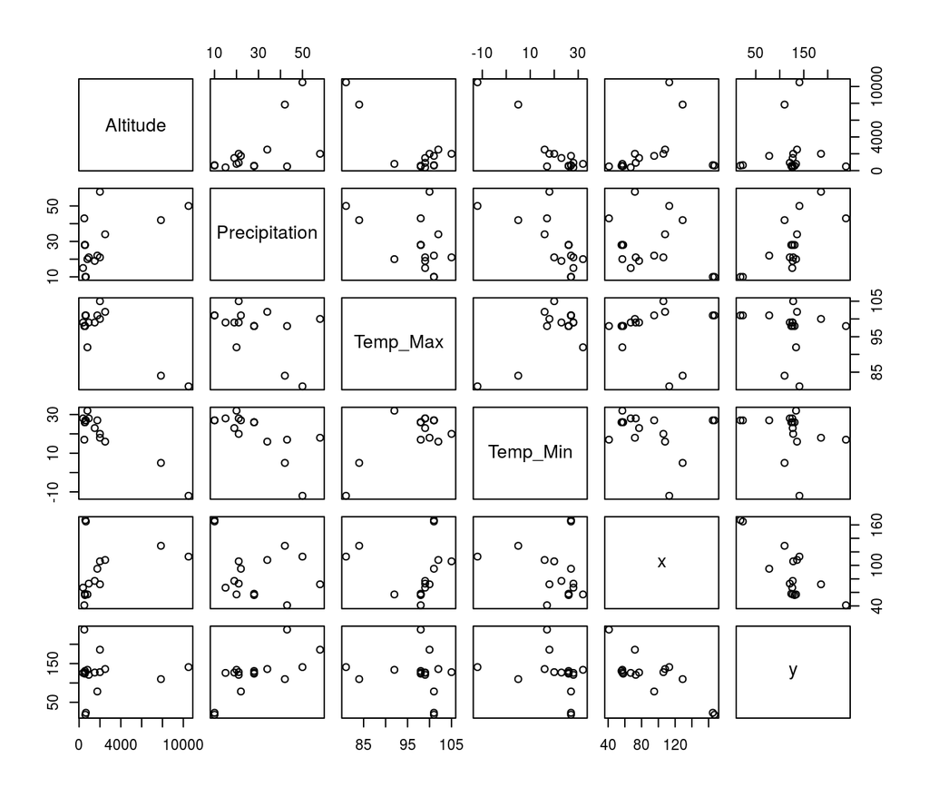

```r
pairs(env_geo)
```

## Удаляем коллинеарные предикторы

Не будем учитывать предикторы у которых VIF >= 10 (Borcard et al. 2011)

```r
library(car)
vif(lm(gen$`0.4` ~ ., data = env_geo))
```

```
##      Altitude Precipitation      Temp_Max      Temp_Min             x
##         23.89          4.46          4.77         22.49          7.54
##             y
##         11.25
```

```r
vif(lm(gen$`0.4` ~ . -Temp_Min, data = env_geo))
```

```
##      Altitude Precipitation      Temp_Max             x             y
##          7.52          4.41          4.61          5.61          7.27
```

- Минимальная температура связана с высотой. Придется оставить что-то одно. Не будем использовать минимальную температуру.

## RDA в R

## RDA в vegan

- Зависимые переменные (отклики) — генетические данные
- Независимые переменные (предикторы) — переменные среды

```r
library(vegan)
bf_rda <- rda(gen ~ Altitude + Precipitation + Temp_Max, data = env_geo)
summary(bf_rda)
```

```
##
## Call:
## rda(formula = gen ~ Altitude + Precipitation + Temp_Max, data = env_geo)
##
## Partitioning of variance:
##               Inertia Proportion
## Total             730      1.000
## Constrained       372      0.509
## Unconstrained     358      0.491
##
## Eigenvalues, and their contribution to the variance
##
## Importance of components:
##                          RDA1    RDA2    RDA3     PC1     PC2     PC3
## Eigenvalue            352.481 18.4680 0.78079 212.437 108.097 27.2173
## Proportion Explained    0.483  0.0253 0.00107   0.291   0.148  0.0373
## Cumulative Proportion   0.483  0.5084 0.50950   0.801   0.949  0.9861
##                          PC4    PC5
## Eigenvalue            8.9505 1.1684
## Proportion Explained  0.0123 0.0016
## Cumulative Proportion 0.9984 1.0000
##
## Accumulated constrained eigenvalues
## Importance of components:
##                          RDA1    RDA2   RDA3
## Eigenvalue            352.481 18.4680 0.7808
## Proportion Explained    0.948  0.0497 0.0021
## Cumulative Proportion   0.948  0.9979 1.0000
##
## Scaling 2 for species and site scores
## * Species are scaled proportional to eigenvalues
## * Sites are unscaled: weighted dispersion equal on all dimensions
## * General scaling constant of scores:  10.2
##
##
## Species scores
##
##        RDA1    RDA2    RDA3    PC1     PC2    PC3
## 0.4   0.679 -0.5790  0.2162 -0.947 -0.5512  0.187
## 0.6   0.910 -0.7304 -0.1210 -2.230 -0.7603  1.000
```

[output cut: 39 more lines]

```
## DP   1.275 -1.308  0.213  5.84888 -6.7130  0.182
## PZ   1.283 -0.832  2.066 -1.50605  2.6764 -5.186
## MC  -2.232  6.462  2.312 -1.50866 -2.2541  1.324
## IF   0.176  1.054  4.091 -0.00751  1.0052  2.605
## AF   1.999 -1.127  5.286  0.74623  3.1376  3.036
## GH  -4.958 -2.619 -0.750 -0.10697 -0.7903 -0.573
## GL  -6.853 -3.390  1.158 -0.13183  0.5484 -0.270
##
##
## Biplot scores for constraining variables
##
##                 RDA1   RDA2  RDA3 PC1 PC2 PC3
## Altitude      -0.885 -0.403 0.231   0   0   0
## Precipitation -0.834  0.524 0.175   0   0   0
## Temp_Max       0.868  0.350 0.353   0   0   0
```

## Структура общей изменчивости

О структуре изменчивости можно судить **по суммам собственных чисел ординационных осей** (ограниченных и неограниченных)

```
## Partitioning of variance:
```

```
##               Inertia Proportion
## Total             730      1.000
## Constrained       372      0.509
## Unconstrained     358      0.491
```

- Total — для всех осей, общая изменчивость исходной матрицы откликов (генетич. структуры в разных сайтах)
- Constrained — для осей, кот. являются комбинациями предикторов (изменчивость объясненная средой)
- Unconstrained — необъясненная предикторами изменчивость

## Важность различных компонент

Можно более подробно оценить, как распределяется изменчивость между осями

```
## Eigenvalues, and their contribution to the variance
```

```
## Importance of components:
##                          RDA1    RDA2    RDA3     PC1     PC2     PC3
## Eigenvalue            352.481 18.4680 0.78079 212.437 108.097 27.2173
## Proportion Explained    0.483  0.0253 0.00107   0.291   0.148  0.0373
## Cumulative Proportion   0.483  0.5084 0.50950   0.801   0.949  0.9861
##                          PC4    PC5
## Eigenvalue            8.9505 1.1684
## Proportion Explained  0.0123 0.0016
## Cumulative Proportion 0.9984 1.0000
```

- Много изменчивости объяснено, но много осталось необъясненной. Первые две ограниченных оси объясняют 51% изменчивости, но первые две неограниченных объясняют еще 43%

## Распределение изменчивости, потенциально объяснимой факторами

```
## Accumulated constrained eigenvalues
```

```
## Importance of components:
##                          RDA1    RDA2   RDA3
## Eigenvalue            352.481 18.4680 0.7808
## Proportion Explained    0.948  0.0497 0.0021
## Cumulative Proportion   0.948  0.9979 1.0000
```

- Первая ограниченная ось объясняет большую часть потенциально объяснимой изменчивости. Остальные оси почти ничего не объясняют.

## Собственные векторы, нагрузки переменных = “species scores”

```r
scores(bf_rda, display = "species", choices = 1:5)
```

```
##        RDA1    RDA2    RDA3    PC1     PC2
## 0.4   0.679 -0.5790  0.2162 -0.947 -0.5512
## 0.6   0.910 -0.7304 -0.1210 -2.230 -0.7603
## 0.8   2.617 -0.0559 -0.1852 -2.772  0.0314
## 1    -6.306  0.1200 -0.0531  3.396 -2.5090
## 1.16  1.515  1.3249  0.0315  2.304  2.6504
## 1.3   0.586 -0.0796  0.1115  0.249  1.1387
## attr(,"const")
## [1] 10.2
```

## Корреляции между откликами и предикторами

- Сильная корреляция между генетической структурой и средой только для первой ограниченной оси. Для других — умеренные или слабые.

```r
spenvcor(bf_rda)
```

```
##  RDA1  RDA2  RDA3
## 0.830 0.348 0.166
```

## Визуализация ординации

## Визуализация ординации

- Какие предикторы важнее всего?
- Какими факторами определяется значение зависимых переменных?

### Триплоты:

- переменные-отклики ("species"),
- объекты ("sites")
- переменные-предикторы (непрерывные в виде векторов, дискретные в виде центроидов)

### Биплоты:

- отклики + предикторы
- объекты + предикторы

## Триплот корреляций (scaling = 2): Какие переменные среды сильнее всего определяют сходство объектов?

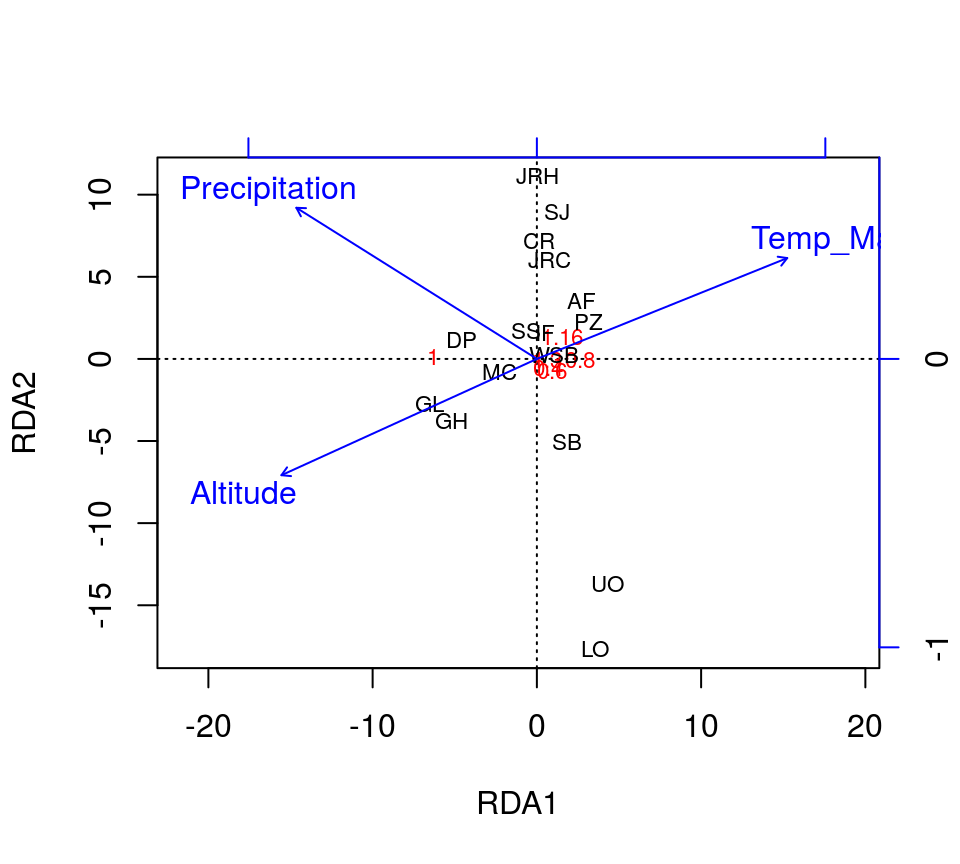

```r
plot(bf_rda, scaling = 2)
```

- Векторы — независимые переменные, факторы среды
- Надписи — объекты (сайты, особи, популяции и пр.)
- Красные надписи —- зависимые переменные
- Косинусы углов между векторами — корреляции между соотв. переменными
- Расстояния между объектами не имеют конкретного смысла
- Проекция объекта на линию-вектор — значение переменной для данного объекта

## Пример интерпретации триплота корреляций

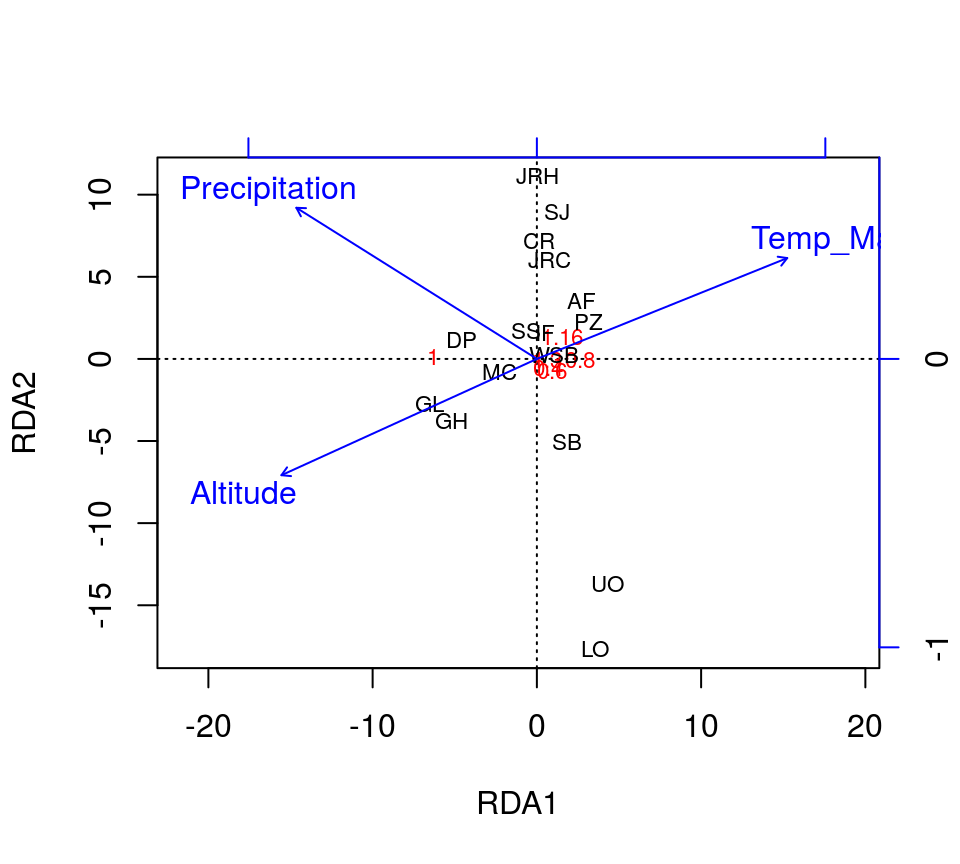

```r
plot(bf_rda, scaling = 2)
```

- Вдоль первой оси изменяется температура, высота и осадки
- Вдоль второй оси — немного меняется уровень осадков

## Триплот расстояний (scaling = 1): Насколько похожи друг на друга объекты?

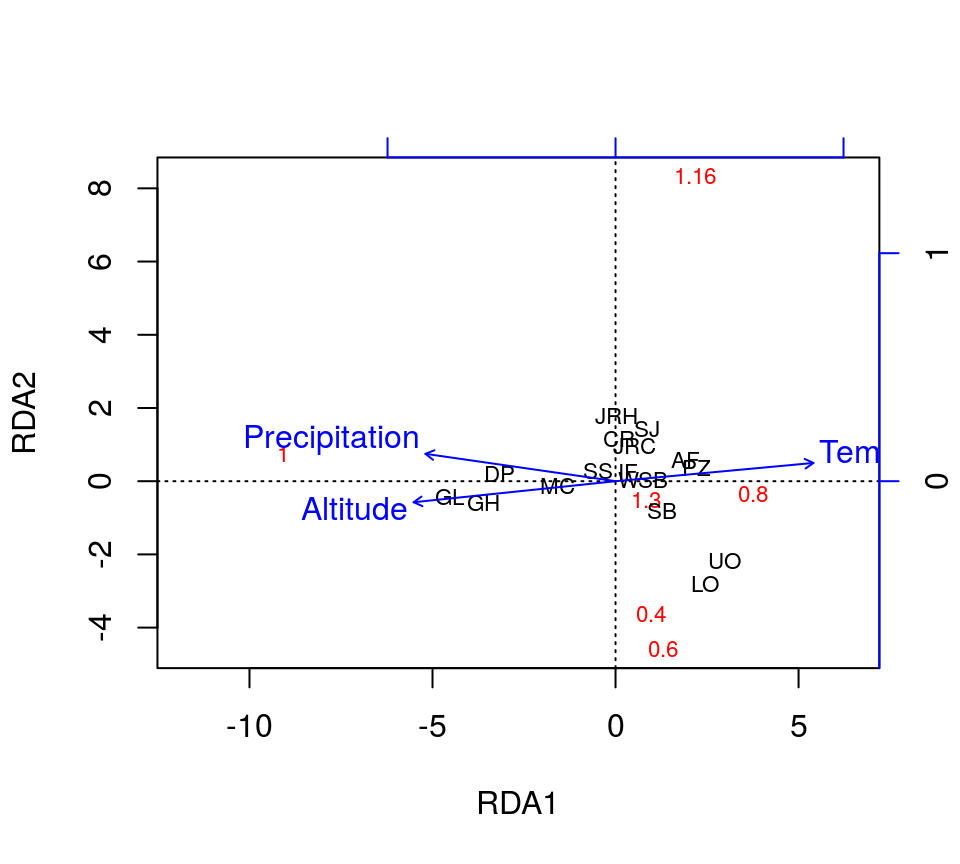

```r
plot(bf_rda, scaling = 1)
```

- Надписи — объекты (сайты, особи, популяции и пр.)
- Красные надписи — зависимые переменные
- Векторы — независимые переменные, факторы среды
- Расстояния между точками — расстояния между наблюдениями
- Косинусы углов между векторами предикторов и откликов — корреляции между соотв. переменными, другие углы не имеют смысла
- Проекция объекта на линию-вектор отражает примерное относительное положение данного объекта вдоль соотв. переменной (но не значение)
- Отношения между дискретными и непрерывными предикторами не интерпретируются

## Пример интерпретации триплота расстояний

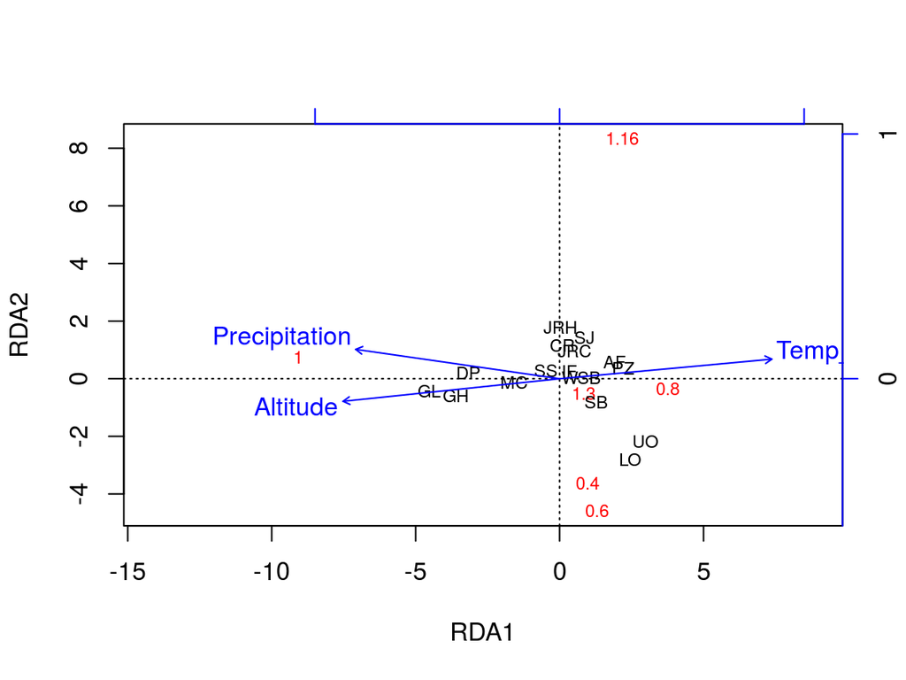

```r
plot(bf_rda, scaling = 1)
```

- Генетическая структура в LO и UO похожа, но не похожа на остальные места
- GL и GH — более высокогорные сайты, чем LO и UO

## Проверка значимости ординации

## Проверкить значимость ординации можно несколькими способами

Каждый из способов дает ответ на свой собственный вопрос.

### Влияют ли факторы на зависимые переменные?

общий тест значимости ординации

### Какие именно факторы влияют на зависимые переменные?

тест факторов по отдельности (Type I или Type III эффекты)

### Значима ли изменчивость вдоль осей ординации?

тест каждой из осей ординации

## Пермутационный тест

- Делаем случайную перестановку данных в матрице зависимых переменных
- Оцениваем качество модели. На основе сумм собственных чисел ограниченных и неограниченных осей рассчитываем статистику — псевдо-F

\[pseudoF = \frac {\Lambda_{c} / p} {\Lambda_{r}/(n - p - 1)}\]

\(\Lambda_{c}\) — инерция ограниченных осей, а \(\Lambda_{r}\) — остаточная инерция (тогда \(\Lambda_{c} + \Lambda_{r} = \Lambda\) — общая инерция), \(p\) — ранг ограниченных осей, \(n\) — число наблюдений  
Псевдо-F построена по тем же принципам, что F в ANOVA, но не следует F-распределению (кроме единственного частного случая RDA c одной переменной). Поэтому нам нужны пермутации, чтобы оценить форму ее распределения.

- По распределению пермутационной статистики оцениваем долю пермутаций, в которых качество модели оказалось лучше, чем для реальной модели — это доверительная вероятность \(p\). Если в большинстве пермутаций получаются модели хуже, чем реальная модель, то значит зависимость от предикторов значима.

## Общий тест на значимость ординации

- тестируем гипотезу о том, что отношения между генотипом и средой значимы.

\(H _0\): значения предикторов в пробах не зависят от переменных среды (генетическая структура не зависит от среды)

## Общий тест: Влияют ли факторы на зависимые переменные?

### Есть ли связь генетики со средой?

```r
anova(bf_rda, permutations = 9999)
```

```
## Permutation test for rda under reduced model
## Permutation: free
## Number of permutations: 9999
##
## Model: rda(formula = gen ~ Altitude + Precipitation + Temp_Max, data = env_geo)
##          Df Variance    F Pr(>F)
## Model     3      372 4.15  0.007 **
## Residual 12      358
## ---
## Signif. codes:  0 '***' 0.001 '**' 0.01 '*' 0.05 '.' 0.1 ' ' 1
```

- связь генетической структуры и среды значима

## Тест факторов, type I эффекты: Какие факторы влияют на зависимые переменные?

```r
anova(bf_rda, by = "term", permutations = 9999)
```

```
## Permutation test for rda under reduced model
## Terms added sequentially (first to last)
## Permutation: free
## Number of permutations: 9999
##
## Model: rda(formula = gen ~ Altitude + Precipitation + Temp_Max, data = env_geo)
##               Df Variance    F Pr(>F)
## Altitude       1      279 9.37 0.0018 **
## Precipitation  1       72 2.43 0.1003
## Temp_Max       1       20 0.67 0.5167
## Residual      12      358
## ---
## Signif. codes:  0 '***' 0.001 '**' 0.01 '*' 0.05 '.' 0.1 ' ' 1
```

## Тест факторов, type III эффекты: Какие факторы влияют на зависимые переменные?

```r
anova(bf_rda, by = "mar", permutations = 9999)
```

```
## Permutation test for rda under reduced model
## Marginal effects of terms
## Permutation: free
## Number of permutations: 9999
##
## Model: rda(formula = gen ~ Altitude + Precipitation + Temp_Max, data = env_geo)
##               Df Variance    F Pr(>F)
## Altitude       1       12 0.41   0.67
## Precipitation  1       71 2.39   0.11
## Temp_Max       1       20 0.67   0.52
## Residual      12      358
```

- Если протестировать каждый из факторов отдельно, при у словии, что все остальные включены в модель, то получится, что ни один из них не влияет.

## Тест значимости осей, ограниченных факторами:

- \(H _0\): значения переменных-откликов для объектов не зависят от переменных-предикторов
- пермутационный: выбирает оси, которые объясняют больше изменчивости, чем из др. матриц, полученных путем перестановок

## Тест значимости осей, ограниченных факторами: Вдоль какой из осей значимо меняется генетическая структура?

```r
anova(bf_rda, by = "axis", permutations = 9999)
```

```
## Permutation test for rda under reduced model
## Forward tests for axes
## Permutation: free
## Number of permutations: 9999
##
## Model: rda(formula = gen ~ Altitude + Precipitation + Temp_Max, data = env_geo)
##          Df Variance     F Pr(>F)
## RDA1      1      352 11.82 0.0047 **
## RDA2      1       18  0.62 0.8532
## RDA3      1        1  0.03 0.9974
## Residual 12      358
## ---
## Signif. codes:  0 '***' 0.001 '**' 0.01 '*' 0.05 '.' 0.1 ' ' 1
```

- Генетическая структура значимо меняется вдоль первой главной оси

## Выбор оптимальной модели

## Выбор оптимальной модели

У нас проблема. Если мы тестируем любой из факторов, после включения остальных в модель — он не влияет. Это значит, что модель не оптимальна.

Как подобрать оптимальную модель?

- Можно использовать пошаговый выбор модели: добавляем в модель лучшие переменные и снова исключаем те, что потеряли значимость. (Вспомните, как это было для регрессионных моделей.)

Какой можно использовать тест для сравнения моделей?

- Модели с разным числом предикторов можно сравнить при помощи пермутационного теста (AIC для ограниченных ординаций не существует!)
- **Осторожно!**
- Пошаговый выбор модели — не панацея, т.к. разные пошаговые методы могут дать разные конечные модели!
- Не запихивайте в модель сразу все предикторы, а начинайте ваш выбор с небольшого числа важных факторов.
- В `vegan` факторы включенные в модель обозначаются "-", а факторы, исключенные из модели — "+"

## Пошаговый выбор оптимальной модели

Для пошагового выбора нам понадобятся полная и нулевая модели

```r
m1 <-rda(gen ~ Altitude + Precipitation + Temp_Max, data = env_geo)
m0 <- rda(gen ~ 1, data = env_geo)
```

Запускаем пошаговый выбор

```r
m <- ordistep(m0, scope = formula(m1), permutations = 9999)
```

```
##
## Start: gen ~ 1
##
##                 Df AIC    F Pr(>F)
## + Altitude       1 101 8.69 0.0019 **
## + Temp_Max       1 101 8.12 0.0033 **
## + Precipitation  1 102 7.30 0.0036 **
## ---
## Signif. codes:  0 '***' 0.001 '**' 0.01 '*' 0.05 '.' 0.1 ' ' 1
##
## Step: gen ~ Altitude
##
##            Df AIC    F Pr(>F)
## - Altitude  1 106 8.69 0.0024 **
## ---
## Signif. codes:  0 '***' 0.001 '**' 0.01 '*' 0.05 '.' 0.1 ' ' 1
##
##                 Df   AIC    F Pr(>F)
## + Precipitation  1  99.9 2.49  0.092 .
## + Temp_Max       1 102.0 0.64  0.548
## ---
## Signif. codes:  0 '***' 0.001 '**' 0.01 '*' 0.05 '.' 0.1 ' ' 1
```

## Оптимальная модель, отобранная при помощи пошагового алгоритма

```r
m$anova
```

```
##            Df AIC    F Pr(>F)
## + Altitude  1 101 8.69 0.0019 **
## ---
## Signif. codes:  0 '***' 0.001 '**' 0.01 '*' 0.05 '.' 0.1 ' ' 1
```

- Оптимальная модель содержит только один предиктор — высоту

## Частный анализ избыточности

## Зачем нужен **частный** анализ избыточности?

Мы уже обнаружили тесную связь генотипов со средой, и даже знаем, с какими переменными.

Но генотипы в близких местах могут быть похожи по разным причинам.

И теперь у нас два вопроса:

### Кто виноват?

- сходный климат в близких локациях
- поток генов между близкими колониями облегчен

### Что делать?

- Нужно удалить влияние географического положения, чтобы сделать корректный вывод о связи генотипов со средой.

## Частный анализ избыточности

- зависимость от одного набора переменных (предикторов), когда влияние другого (ковариат) исключено.

Техника:

1. Множественная регрессия зависимости предикторов от ковариат.
2. Остатки от этой регрессии — это то, что от ковариат не зависит — можно использовать в PCA в качестве предикторов (вместо исходных переменных среды).

Legendre & Legendre 1998

## Делаем частный RDA: зависимость генетической структуры от среды с учетом географического положения

```r
bf_prda_1 <- rda(gen ~ Altitude + Condition(x + y), data = env_geo)
anova(bf_prda_1, permutations = 9999) ## Пермутационный тест
```

```
## Permutation test for rda under reduced model
## Permutation: free
## Number of permutations: 9999
##
## Model: rda(formula = gen ~ Altitude + Condition(x + y), data = env_geo)
##          Df Variance    F Pr(>F)
## Model     1      213 9.94 0.0008 ***
## Residual 12      257
## ---
## Signif. codes:  0 '***' 0.001 '**' 0.01 '*' 0.05 '.' 0.1 ' ' 1
```

- Высота объясняет генетическую изменчивость, даже после удаления влияния географической близости

## График ординации

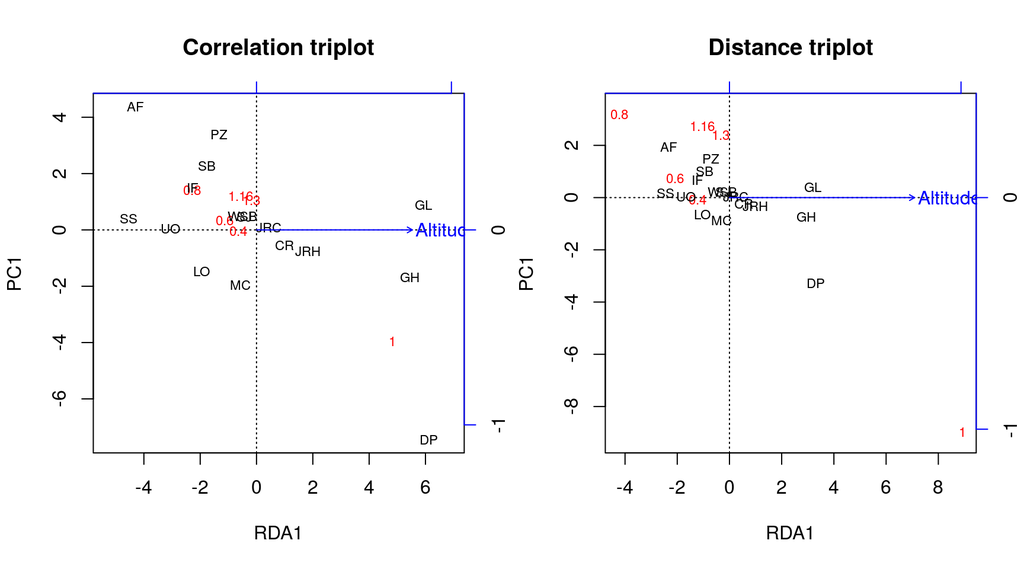

```r
op <- par(mfrow = c(1, 2))
plot(bf_prda_1, main = "Correlation triplot", scaling = 2)
plot(bf_prda_1, main = "Distance triplot", scaling = 1)
```

```r
par(op)
```

## Компоненты объясненной инерции

## Компоненты инерции

К этому моменту мы знаем, что среда объясняет генетическую изменчивость, даже после удаления влияния географических координат.

Но какая часть изменчивости генетической структуры объясняется в чистом виде географической близостью, а какая — общим действием среды и географии?

## Общую инерцию делим на части

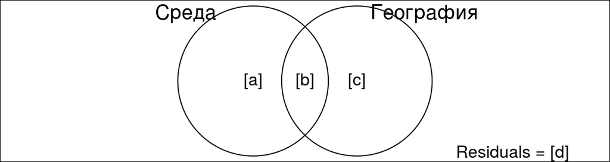

| Компонент инерции | Что описывает? | Инерция |
| --- | --- | --- |
| a + b + c | вся потенциально объяснимая средой и географией изменчивость | Объясненная ограниченными осями RDA среда + география |
| a | изменчивость, объясненная средой | Объясненная ограниченными осями pRDA среда + Condition(география) |
| с | изменчивость, объясненная географией | Объясненная ограниченными осями pRDA география + Condition(среда) |
| b | изменчивость, совместно объясненная средой и географией | Находим инерцию по разности |

## Подбираем модели RDA, нужные для поиска компонентов инерции

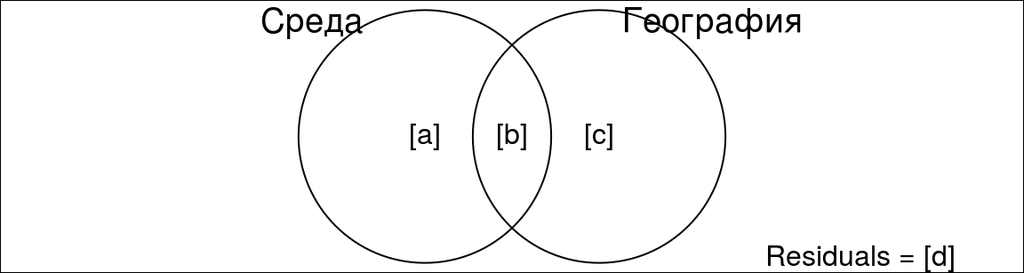

Нам нужна **полная модель RDA: генетика от среды и географического положения** (чтобы найти a + b + c)

У нас уже есть **частный RDA №1: зависимость генетики от среды с учетом географии** (чтобы найти a)

Нам нужен **частный RDA №2: генетика от географии с учетом свойств среды** (чтобы найти c)

```r
bf_prda_2 <- rda(gen ~ x + y + Condition(Altitude), data = env_geo)
bf_rda_full <- rda(gen ~ x + y + Altitude, data = env_geo)
```

## Задание: Найдите компоненты инерции

По результатам трех RDA найдите

всю потенциально объяснимую инерцию,

а так же долю инерции, объясненную:

- средой и географией
- средой, но не с географией
- географией, но не со средой

## Решение: 1) Сколько инерции потенциально объясняется средой и географией?

```r
sum_full <- summary(bf_rda_full)
```

```
> sum_full
```

```
## Partitioning of variance:
```

```
##               Inertia Proportion
## Total             730      1.000
## Constrained       473      0.648
## Unconstrained     257      0.352
```

Инерция, объясненная вместе средой и географией, здесь достаточно велика — 472.64

```r
(I_total <- sum_full$constr.chi)
```

```
## [1] 473
```

В отличие от нее, доля инерции, объясненной ограниченной матрицей, может быть довольно малой по отношению к общей инерции, поэтому можно сосредоточиться на доле от потенциально объяснимой инерции (от `sum_full$constr.chi`)

## Решение: 2) Инерция, объясненная средой

```r
sum_prda_1 <- summary(bf_prda_1)
```

```
> sum_prda_1
```

```r
partit(sum_prda_1)
```

```
## Partitioning of variance:
```

```
##               Inertia Proportion
## Total             730      1.000
## Conditioned       260      0.356
## Constrained       213      0.292
## Unconstrained     257      0.352
```

- Среда без географии объясняет 212.89

```r
(I_env <- sum_prda_1$constr.chi)
```

```
## [1] 213
```

## Решение 3) Инерция, объясненная географией

```r
sum_prda_2 <- summary(bf_prda_2)
```

```
> sum_prda_2
```

```r
partit(sum_prda_2)
```

```
## Partitioning of variance:
```

```
##               Inertia Proportion
## Total             730      1.000
## Conditioned       279      0.383
## Constrained       193      0.265
## Unconstrained     257      0.352
```

География без среды объясняет 193.24

```r
(I_geo <- sum_prda_2$constr.chi)
```

```
## [1] 193
```

## Решение: 4) Инерция, совместно объясненная средой и географией

```r
(I_env_geo <- I_total - I_env - I_geo)
```

```
## [1] 66.5
```

## Компоненты инерции — сводим результаты вместе

```r
comp <- data.frame(Inertia = c(I_env, I_geo, I_env_geo, I_total))
rownames(comp) <- c('Только среда',
                    'Только география',
                    'Среда и география вместе',
                    'Общая объяснимая инерция')
comp$Proportion <- comp$Inertia/sum(comp$Inertia[1:3]) * 100
colnames(comp) <- c('Инерция', '%')
comp
```

```
##                          Инерция     %
## Только среда               212.9  45.0
## Только география           193.2  40.9
## Среда и география вместе    66.5  14.1
## Общая объяснимая инерция   472.6 100.0
```

## Take home messages

- Анализ избыточности помогает установить связь между несколькими наборами переменных. Один из наборов считается зависимым, другой считается объясняющим
- Для анализа необходимо, чтобы зависимости переменных-откликов от предикторов были линейными
- В ходе анализа выделяют два типа осей — ограниченные (объясненные) переменными-предикторами, и неограниченные (необъясненные) ими
- Частный анализ избыточности позволяет описать зависимость двух наборов переменных с поправкой на влияние дополнительных переменных (ковариат)
- При помощи частного анализа избыточности можно выделить компоненты инерции связанные с несколькими (2–4) наборами переменных-предикторов

## Дополнительные ресурсы

- Borcard, D., Gillet, F., Legendre, P., 2011. Numerical ecology with R. Springer.
- Legendre, P., Legendre, L., 2012. Numerical ecology. Elsevier.
- Oksanen, J., 2011. Multivariate analysis of ecological communities in R: vegan tutorial. R package version 2–0.
- The Ordination Web Page URL http://ordination.okstate.edu/ (accessed 19.04.17).
- Quinn, G.G.P., Keough, M.J., 2002. Experimental design and data analysis for biologists. Cambridge University Press.